# R Notebook

```r
library(ggally)
```

[output not shown]

### Task 1

```r
housing_prices <- read_csv("data/housing_prices.csv") %>%
  clean_names()
summary(housing_prices)
```

```
   longitude         latitude     housing_median_age  total_rooms    total_bedrooms     population      households     median_income     median_house_value
 Min.   :-124.3   Min.   :32.54   Min.   : 1.00      Min.   :    2   Min.   :   2.0   Min.   :    3   Min.   :   2.0   Min.   : 0.4999   Min.   : 14999
 1st Qu.:-121.8   1st Qu.:33.93   1st Qu.:18.00      1st Qu.: 1438   1st Qu.: 297.0   1st Qu.:  796   1st Qu.: 282.0   1st Qu.: 2.5268   1st Qu.:116600
 Median :-118.5   Median :34.27   Median :28.00      Median : 2111   Median : 436.0   Median : 1179   Median : 411.0   Median : 3.4500   Median :173800
 Mean   :-119.6   Mean   :35.65   Mean   :28.39      Mean   : 2620   Mean   : 539.6   Mean   : 1441   Mean   : 501.2   Mean   : 3.6767   Mean   :192478
 3rd Qu.:-118.0   3rd Qu.:37.73   3rd Qu.:37.00      3rd Qu.: 3120   3rd Qu.: 648.0   3rd Qu.: 1746   3rd Qu.: 606.0   3rd Qu.: 4.5826   3rd Qu.:248200
 Max.   :-114.3   Max.   :41.95   Max.   :52.00      Max.   :39320   Max.   :6445.0   Max.   :35682   Max.   :6082.0   Max.   :15.0001   Max.   :500000
                                                                     NA's   :200
 ocean_proximity
 Length:19675
 Class :character
 Mode  :character
```

Looking at the Kaggle website, the `median_income` variable is measured in tens-of-thousands of US Dollars, whilst the `median_house_value` is measured in US Dollars.

Convert `median_income` to US Dollars.

```r
housing_prices_scaled <- housing_prices %>%
  mutate(median_income = median_income * 10000)
```

Variable `total_bedrooms` has 200 missing values. Replace with mean of `total_bedrooms`.

```r
housing_prices_scaled <- housing_prices_scaled %>%
  mutate(total_bedrooms = coalesce(total_bedrooms, mean(total_bedrooms, na.rm = TRUE)))
```

Check for aliases.

```r
alias(lm(total_rooms ~., data = housing_prices_scaled))
```

```
Model :
total_rooms ~ longitude + latitude + housing_median_age + total_bedrooms +
    population + households + median_income + median_house_value +
    ocean_proximity
```

No aliases found.

### Task 2

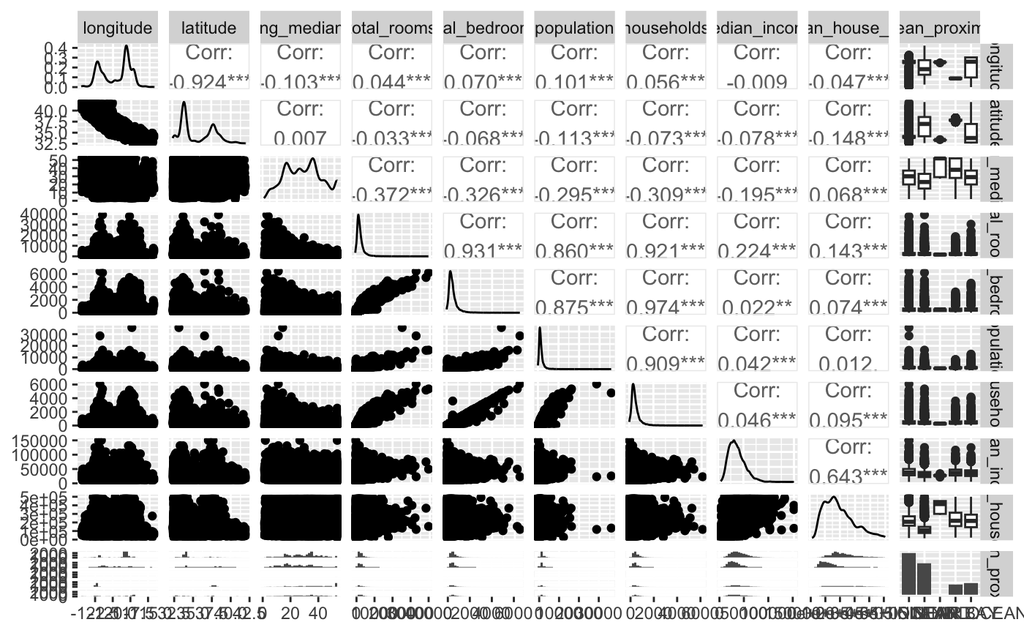

```r
ggpairs(housing_prices_scaled)
```

Correlation between `total_rooms` and `total_bedrooms` is 0.931.

### Task 3

```r
# remove total_bedrooms from dataset
housing_prices_scaled <- housing_prices_scaled %>%
  select(-total_bedrooms)
```

### Task 4

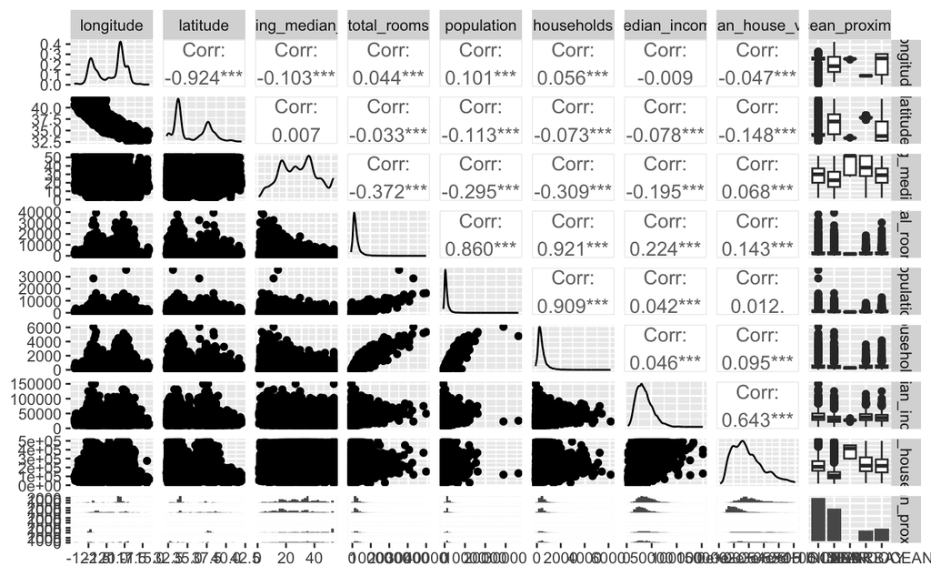

```r
ggpairs(housing_prices_scaled)
```

Looks like there are 3 key variables for `median_house_value`: `latitude`, `total_rooms` and `median_income`

Let’s plot each of these against `median_house_value`.

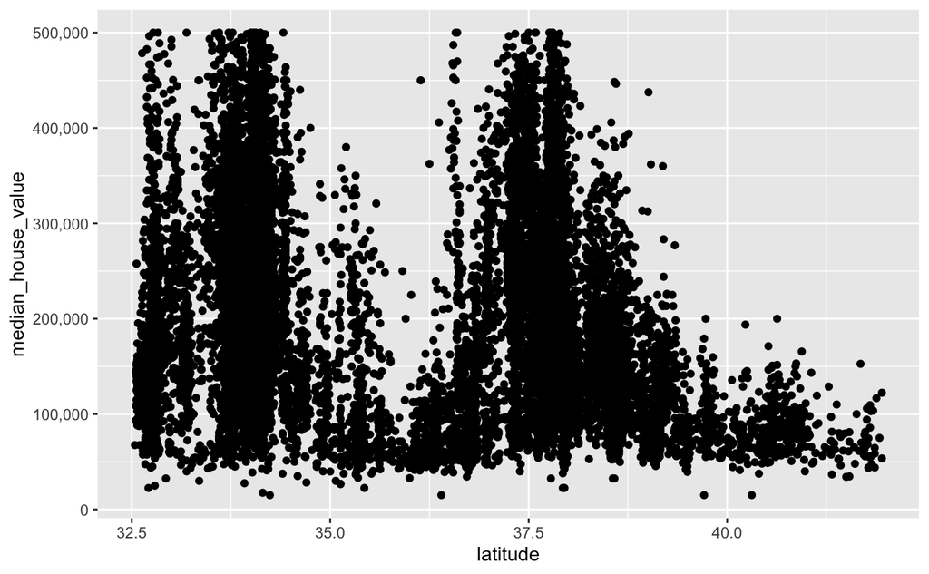

```r
housing_prices_scaled %>%
  ggplot() +
  aes(x = latitude, y = median_house_value) +
  geom_point() +
  scale_y_continuous(labels = scales::comma)
```

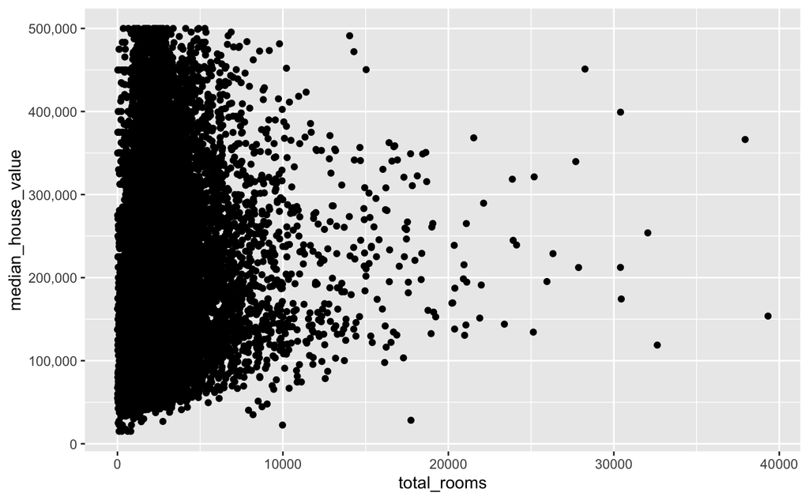

```r
housing_prices_scaled %>%
  ggplot() +
  aes(x = total_rooms, y = median_house_value) +
  geom_point() +
  scale_y_continuous(labels = scales::comma)
```

`total_rooms` is the number of rooms in a block. Divide this by number of households to get average rooms per household:

```r
housing_prices_scaled <- housing_prices_scaled %>%
  mutate(avg_rooms_per_house = total_rooms / households)
```

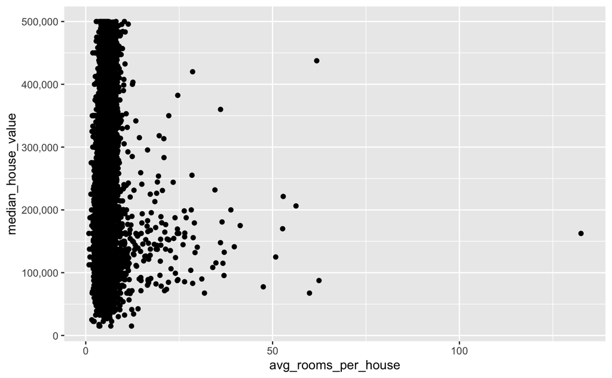

```r
housing_prices_scaled %>%
  ggplot() +
  aes(x = avg_rooms_per_house, y = median_house_value) +
  geom_point() +
  scale_y_continuous(labels = scales::comma)
```

Plenty of outliers in the `avg_rooms_per_house` variable

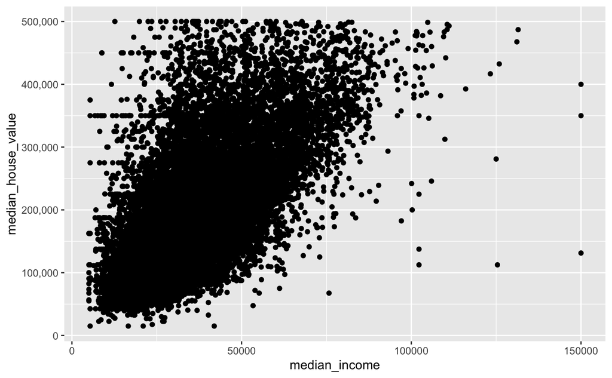

```r
housing_prices_scaled %>%
  ggplot() +
  aes(x = median_income, y = median_house_value) +
  geom_point() +
  scale_y_continuous(labels = scales::comma)
```

### Task 5

```r
housing_prices_scaled %>%
  distinct(ocean_proximity)
```

| ocean_proximity |
| --- |
| NEAR BAY |
| <1H OCEAN |
| INLAND |
| NEAR OCEAN |
| ISLAND |

There are 5 unique values/levels within `ocean_proximity`, so that means you require n - 1 dummy variables, which is 4.

### Task 6

[figure not shown]

residuals vs fitted: looks ok with residuals randomly scattered around zero normal q-q: looks ok-ish but outliers at the low and high end distort the normal distribution scale-location: definite funnelling effect

```r
summary(house_model)
```

```
Call:
lm(formula = median_house_value ~ median_income, data = housing_prices_scaled)

Residuals:
    Min      1Q  Median      3Q     Max
-513966  -51564  -13979   36549  403935

Coefficients:
               Estimate Std. Error t value Pr(>|t|)
(Intercept)   4.546e+04  1.359e+03   33.45   <2e-16 ***
median_income 3.999e+00  3.399e-02  117.64   <2e-16 ***
---
Signif. codes:  0 ‘***’ 0.001 ‘**’ 0.01 ‘*’ 0.05 ‘.’ 0.1 ‘ ’ 1

Residual standard error: 74870 on 19673 degrees of freedom
Multiple R-squared:  0.4129,    Adjusted R-squared:  0.4129
F-statistic: 1.384e+04 on 1 and 19673 DF,  p-value: < 2.2e-16
```

**Conclusion** house_model produces a r^2 value of 0.4129 with a statistically significant p-value.

### Task 7

Add `total_rooms` to the model.

```r
housing_prices_scaled %>%
  summarise(cor = cor(median_house_value, total_rooms))
```

| cor |
| --- |
| 0.1431387 |

A very weak positive correlation between the two variables. Great!

Nevertheless, add it to the model:

```r
house_model_2 <- lm(median_house_value ~ median_income + total_rooms,
                    data = housing_prices_scaled)
```

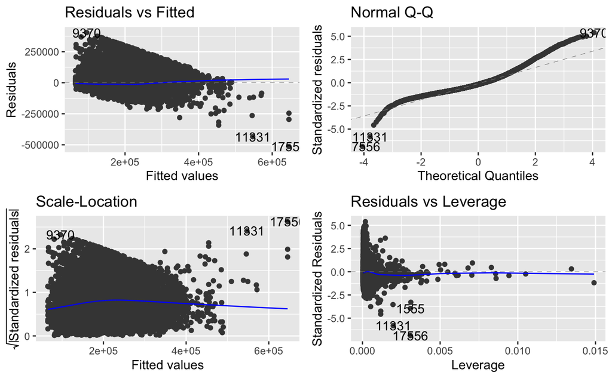

```r
# diagnostics
autoplot(house_model_2)
```

Very similar to the first model.

residuals vs fitted: looks ok with residuals randomly scattered around zero normal q-q: looks ok-ish but outliers at the low and high end distort the normal distribution scale-location: definite funnelling effect

```r
summary(house_model_2)
```

```
Call:
lm(formula = median_house_value ~ median_income + total_rooms,
    data = housing_prices_scaled)

Residuals:
    Min      1Q  Median      3Q     Max
-514229  -51548  -13949   36541  403882

Coefficients:
                Estimate Std. Error t value Pr(>|t|)
(Intercept)    4.552e+04  1.409e+03  32.318   <2e-16 ***
median_income  4.000e+00  3.488e-02 114.679   <2e-16 ***
total_rooms   -4.428e-02  2.511e-01  -0.176     0.86
---
Signif. codes:  0 ‘***’ 0.001 ‘**’ 0.01 ‘*’ 0.05 ‘.’ 0.1 ‘ ’ 1

Residual standard error: 74870 on 19672 degrees of freedom
Multiple R-squared:  0.4129,    Adjusted R-squared:  0.4129
F-statistic:  6919 on 2 and 19672 DF,  p-value: < 2.2e-16
```

**Conclusion:** house_model_2 does not change let alone improve on the r^2 value of 0.4129 from the first house_model. Indeed, the p-value for `total_rooms` indicates that as a predictor it is not statistically significant.